# Fremmede arter på fjellet

## Beskrivelse

Fremmede arter kan endre økologiske funskjoner og utkonkurrere hjemlige arter. Det er imidlertidig få fremmede arter på fjellet i dag. Her viser vi først kunnskapsstatus for påvirkningsfaktoren fremmedartsintroduksjoner i fjelløkosystemer fra Fremmedartslisten 2018, og så evaluerer vi data fra overvåkingsprogrammet ANO fra årene 209-2021 for fremmede plantearter.

## Data import & handling

This document includes two data sets:

Alien species introductions form Fremmedartslista 2018 (pressure data)  
ANO data 2018-2021 (ecological condition data)  
- geography  
- locations

# Pressure indicator ‘Introduction of alien species’

We can plot the cumulative introduction of alien species over time for each region

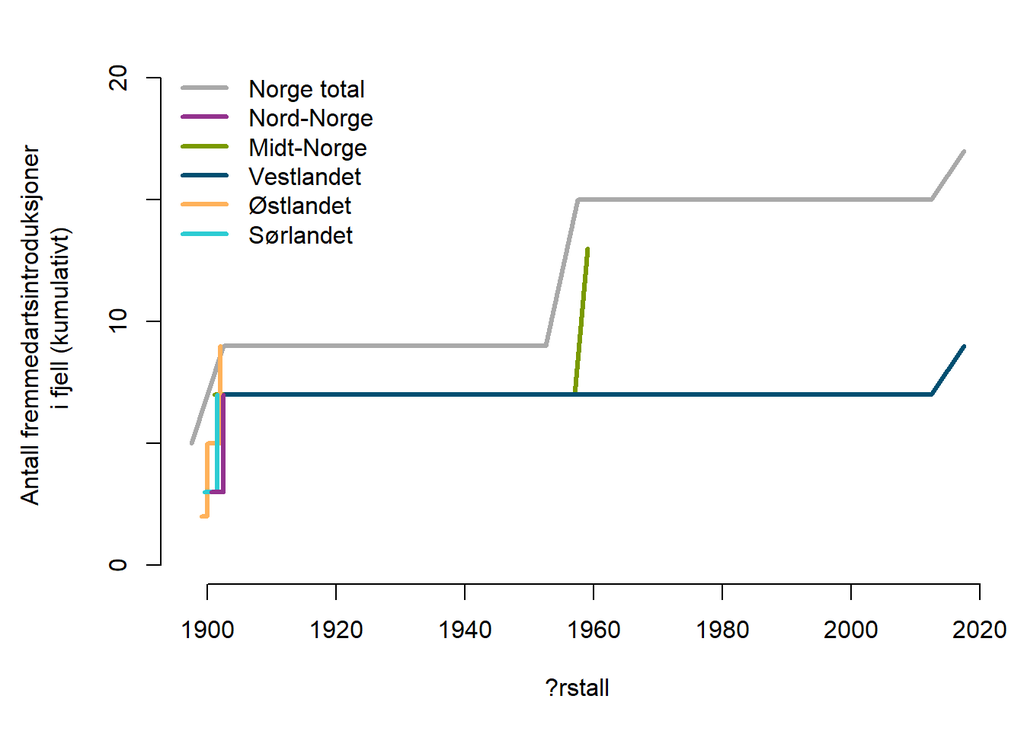

The introductions cover 17 species within 2 kingdoms - all 11 animal species are birds

```
##   Plantae Fungi Chromista Animalia Aves
## 1       6     0         0       11   11
```

The introductions cover 3 ecosystem types

```
##   Fjellhei_leside_tundra Snøleie Rabbe Fjellgrashei
## 1                     12       2     0            3
```

# Condition indicator ‘Area without cover of alien plant species’

We define the reference value to reflect the abscence of alien species (i.e. 100% cover without alien species), the limit value for good ecological condition is set to 95% (expert-opinion based), and the minimum value is 0.

```r
alien.ref <- data.frame(ref=100,lim=95,min=0)
```

Next we scale the alien species cover data against the threshold values in alien.ref.

Here is the result for Norway

```r
# overall result
summary(results.mount.alien[['scaled']][,'alien'])
```

```
##    Min. 1st Qu.  Median    Mean 3rd Qu.    Max.    NA's
##  0.4421  1.0000  1.0000  0.9993  1.0000  1.0000     199
```

and by region (C = Central, E = Eastern, N = Northern, S = Southern, W = Western)

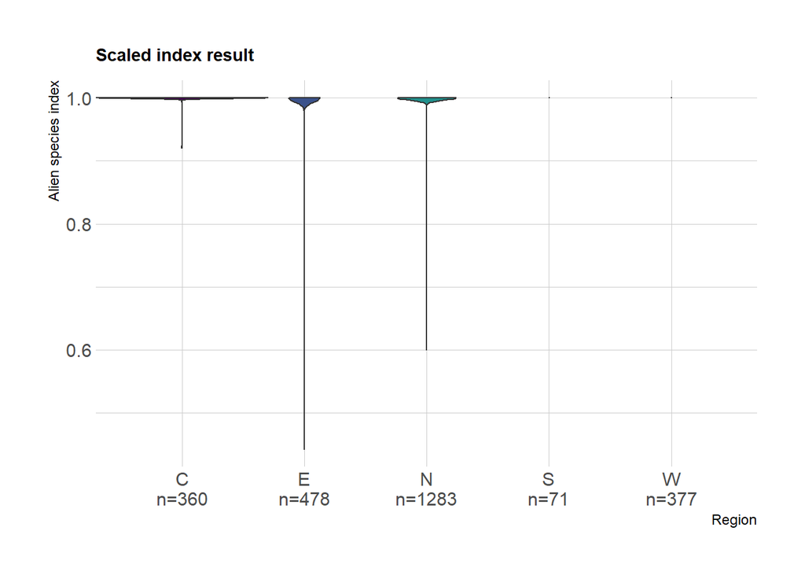

Most indices are equal or close to 1 (optimal). Serious deviations do occur in Eastern and Northern Norway, but they are very seldom. Southern and Western Norway do not have a single index value below 1, i.e. there were no alien species registrations at all.

Klikk here to see the next step in the analysis, aggregation and standardization of the indicator data set.